# Guía Regresión lineal múltiple

OCE 386 - Introducción al análisis de datos con R.

Dr. José A. Gallardo.

Pontificia Universidad Católica de Valparaíso  
jose.gallardo@pucv.cl

16 November 2021

### MODELOS LINEALES

Sea $Y$ una variable respuesta continua y $X_1,…,X_p$ variables predictoras, un modelo de regresión lineal múltiple se puede representar como,

$$Y_{i} = \beta_{0} + \beta_{1} X_{i1} + \beta_{2} X_{i2} + ... + \beta_{p} X_{ip} + \epsilon_{i}$$

Supuestos:

1. No existe multicolinealidad.
2. Los residuos distribuyen **normalmente**.
3. Existe homogeneidad de varianzas.

#### **Objetivos de aprendizaje**

Los objetivos de aprendizaje de esta guía son:

**1**. - Realizar análisis de regresión lineal múltiple.

**2**. - Realizar gráficas avanzadas con ggplot2.

**3**. - Elaborar un reporte dinámico en formato pdf con **[Rmarkdown](https://rmarkdown.rstudio.com/)**.

## ESTUDIO DE CASO: SET DE DATOS GALA

En esta guía continuaremos trabajando con el set de datos **gala** de la librería **faraway**, pero ahora estudiaremos como variable respuesta el número de especies endémicas **Endemics**.

### **Ejercicio 1.** Elaborar y configurar Reporte en formato .Rmd

Elabore un documento .Rmd y configure su reporte para exportar en .pdf. Instale solo las liberías que utilice para el análisis de los datos.

```r
knitr::opts_chunk$set(echo = TRUE)
library(readxl)
library(ggplot2)
library(dplyr)
library(multcomp)
library(psych)
library(car)
library(faraway)
library(PerformanceAnalytics)
```

Ejecute cada uno de los siguientes ejercicios en uno o más bloques de códigos diferentes. Sea ordenado y documente su reporte adecuadamente.

### **Ejercicio 2.** Exploratorio set de datos gala.

El set de datos **gala** ya está instalado en R así que solo debe enlazarlo a su sesión de trabajo con el comando **attach(gala)**.

Incluya:

**a).** Realice análisis exploratorio de datos, use **head()** y **summary()**.

```r
attach(gala)
knitr::kable(
  head(gala),
  row.names = TRUE)
```

|  | Species | Endemics | Area | Elevation | Nearest | Scruz | Adjacent |
| --- | --- | --- | --- | --- | --- | --- | --- |
| Baltra | 58 | 23 | 25.09 | 346 | 0.6 | 0.6 | 1.84 |
| Bartolome | 31 | 21 | 1.24 | 109 | 0.6 | 26.3 | 572.33 |
| Caldwell | 3 | 3 | 0.21 | 114 | 2.8 | 58.7 | 0.78 |
| Champion | 25 | 9 | 0.10 | 46 | 1.9 | 47.4 | 0.18 |
| Coamano | 2 | 1 | 0.05 | 77 | 1.9 | 1.9 | 903.82 |
| Daphne.Major | 18 | 11 | 0.34 | 119 | 8.0 | 8.0 | 1.84 |

```r
knitr::kable(
  summary(gala))
```

|  | Species | Endemics | Area | Elevation | Nearest | Scruz | Adjacent |
| --- | --- | --- | --- | --- | --- | --- | --- |
|  | Min. : 2.00 | Min. : 0.00 | Min. : 0.010 | Min. : 25.00 | Min. : 0.20 | Min. : 0.00 | Min. : 0.03 |
|  | 1st Qu.: 13.00 | 1st Qu.: 7.25 | 1st Qu.: 0.258 | 1st Qu.: 97.75 | 1st Qu.: 0.80 | 1st Qu.: 11.03 | 1st Qu.: 0.52 |
|  | Median : 42.00 | Median :18.00 | Median : 2.590 | Median : 192.00 | Median : 3.05 | Median : 46.65 | Median : 2.59 |
|  | Mean : 85.23 | Mean :26.10 | Mean : 261.709 | Mean : 368.03 | Mean :10.06 | Mean : 56.98 | Mean : 261.10 |
|  | 3rd Qu.: 96.00 | 3rd Qu.:32.25 | 3rd Qu.: 59.237 | 3rd Qu.: 435.25 | 3rd Qu.:10.03 | 3rd Qu.: 81.08 | 3rd Qu.: 59.24 |
|  | Max. :444.00 | Max. :95.00 | Max. :4669.320 | Max. :1707.00 | Max. :47.40 | Max. :290.20 | Max. :4669.32 |

**b).** Realice un histograma de la variable respuesta **Endemics** usando ggplot y el comando **geom_hostogram()**.

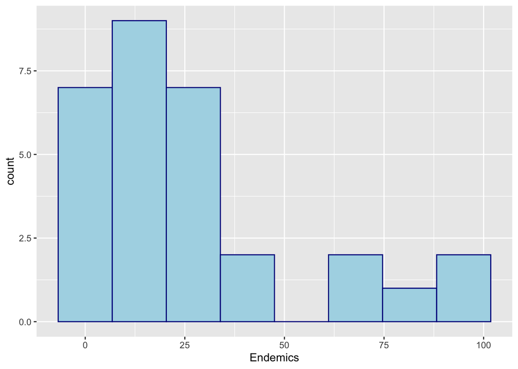

```r
ggplot(gala, aes(x=Endemics))+
  geom_histogram(color="darkblue", fill="lightblue", bins = 8)
```

**c).** Elimine el outlier detectado en clases para la variable AREA con el comando **is.na()** y luego evalue la correlación entre las variables predictoras: Area, Elevation, Nearest, Scruz y Adjacent. Use el comando **chart.Correlation()**.

Elimina outliers

```r
is.na(gala$Area) <- gala$Area >= 3000
```

Extrae variables para analizar

```r
gala_reducido <- gala[, c(3:7)]
```

Realiza gráfica y análisis de correlación

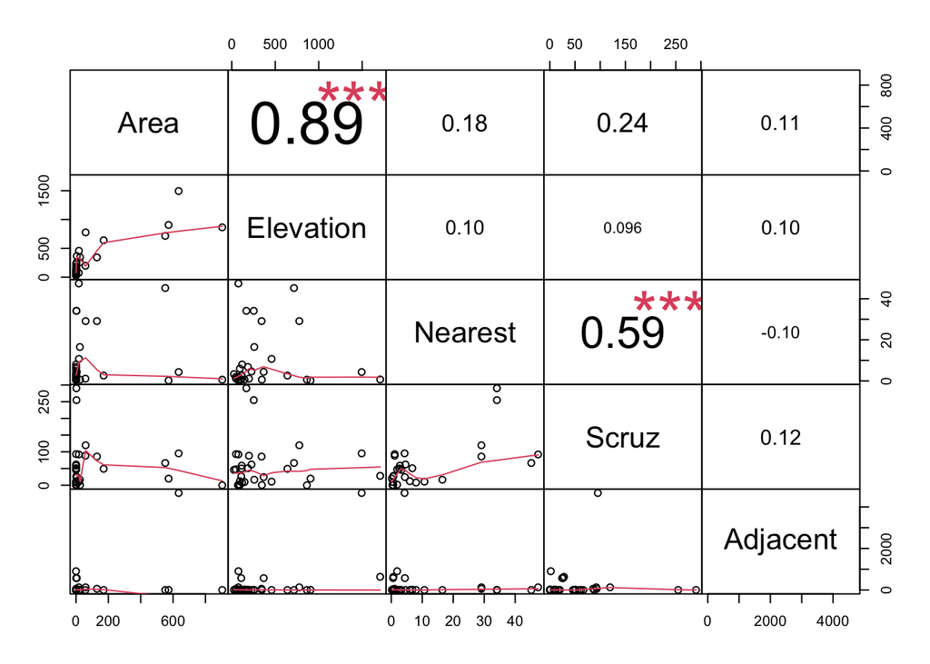

```r
chart.Correlation(gala_reducido, histogram=FALSE, pch=19, method = c("spearman"))
```

### **Ejercicio 3.** Análisis de regresión lineal múltiple.

**a).** Realice un análisis de regresión lineal múltiple completo para investigar la asociación entre **Endemics** y todas las variables predictoras usando las funciones **lm()**, **summary()**.

Interprete los resultados del modelo lineal múltiple y responda las siguientes preguntas:  
- ¿Qué representan los estimadores Beta: Intercept, Area, Elevation, Nearest, Scruz y Adjacent?.  
- ¿Qué estimadores de Beta son significativamente distintas de cero?.  
- ¿Cuál es la bondad de ajuste del modelo $R^2$ ajustado?.  
- ¿Puede predecir el número de especies endémicas con este modelo lineal?.

```r
fitFull <- lm(Endemics ~ Area + Elevation + Nearest +
              Scruz + Adjacent, data=gala)
summary(fitFull)
```

```
##
## Call:
## lm(formula = Endemics ~ Area + Elevation + Nearest + Scruz +
##     Adjacent, data = gala)
##
## Residuals:
##      Min       1Q   Median       3Q      Max
## -13.8756  -5.4949  -0.6781   3.5752  24.8520
##
## Coefficients:
##              Estimate Std. Error t value Pr(>|t|)
## (Intercept)  7.666454   3.199062   2.396 0.025076 *
## Area         0.044412   0.014767   3.008 0.006277 **
## Elevation    0.053910   0.011865   4.544 0.000145 ***
## Nearest     -0.018548   0.172266  -0.108 0.915190
## Scruz       -0.031742   0.035757  -0.888 0.383886
## Adjacent    -0.015821   0.002919  -5.421 1.65e-05 ***
## ---
## Signif. codes:  0 '***' 0.001 '**' 0.01 '*' 0.05 '.' 0.1 ' ' 1
##
## Residual standard error: 9.941 on 23 degrees of freedom
##   (1 observation deleted due to missingness)
## Multiple R-squared:  0.8706, Adjusted R-squared:  0.8425
## F-statistic: 30.96 on 5 and 23 DF,  p-value: 1.729e-09
```

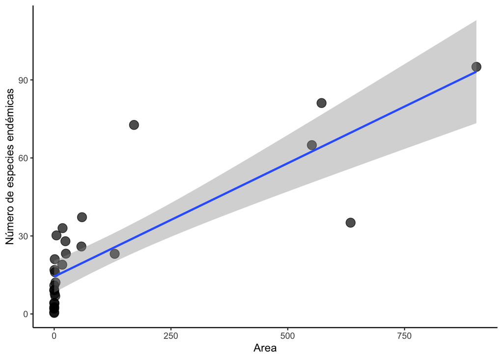

```r
gala %>%
ggplot(aes(Area,Endemics)) +
  geom_jitter(size=4,alpha=0.7) +
  theme_classic() +
   geom_smooth(method="lm", formula=y~x, se=T) +
  scale_color_manual(values=c("blue","red")) +
  xlab("Area") +
  ylab("Número de especies endémicas")
```

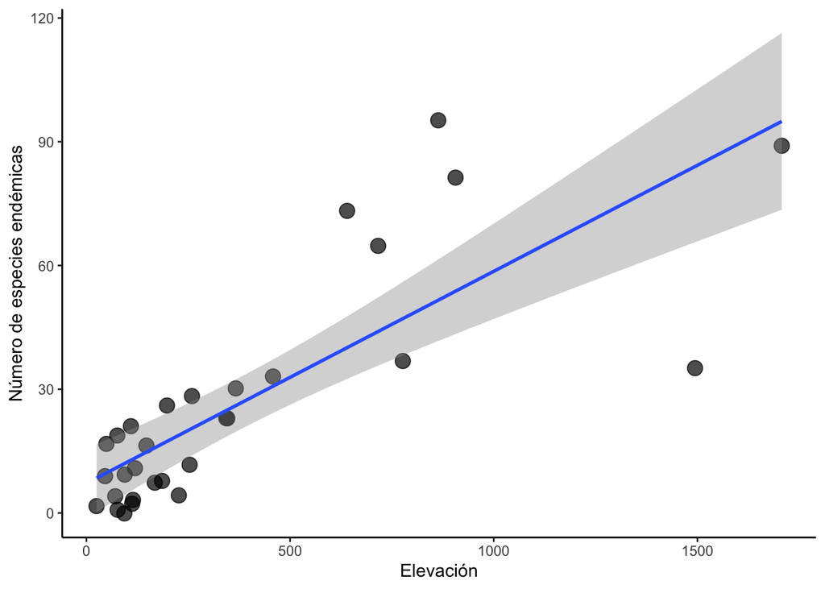

```r
gala %>%
ggplot(aes(Elevation,Endemics)) +
  geom_jitter(size=4,alpha=0.7) +
  theme_classic() +
   geom_smooth(method="lm", formula=y~x, se=T) +
  scale_color_manual(values=c("blue","red")) +
  xlab("Elevación") +
  ylab("Número de especies endémicas")
```

**c).** Realice un análisis de varianza e interprete los resultados, use la función **anova()** sobre el modelo lineal completo. Responda:

- ¿Qué variables influyen significativamente sobre el número de especies endémicas?
- ¿Existe concordancia entre este resultado y la significancia de los coeficientes Beta de Area y Elevación?.

```r
anova(fitFull)
```

```
## Analysis of Variance Table
##
## Response: Endemics
##           Df  Sum Sq Mean Sq  F value    Pr(>F)
## Area       1 11838.8 11838.8 119.7981 1.354e-10 ***
## Elevation  1   230.9   230.9   2.3361   0.14005
## Nearest    1    16.8    16.8   0.1699   0.68403
## Scruz      1   306.8   306.8   3.1042   0.09138 .
## Adjacent   1  2903.7  2903.7  29.3829 1.653e-05 ***
## Residuals 23  2272.9    98.8
## ---
## Signif. codes:  0 '***' 0.001 '**' 0.01 '*' 0.05 '.' 0.1 ' ' 1
```

### **Ejercicio 4.** Evaluación de supuestos modelo completo.

**a).** Investigue como evaluar, evalue e interprete los supuestos de multicolinealidad, normalidad y homogeneidad de varianzas en un análisis de regresión lineal múltiple y responda.

- ¿Se cumple el supuesto de ausencia de multocolinealidad?.
- ¿Se cumple el supuesto normalidad?.
- ¿Se cumple el supuesto homogeneidad de varianzas?.

Multicolinealidad por vif (Variance Inflation Factor).

```r
vif(fitFull)
```

```
##      Area Elevation   Nearest     Scruz  Adjacent
##  3.435458  4.700890  1.747251  1.725422  1.855938
```

Normalidad

```r
shapiro.test (residuals (fitFull))
```

```
##
##  Shapiro-Wilk normality test
##
## data:  residuals(fitFull)
## W = 0.93932, p-value = 0.09626
```

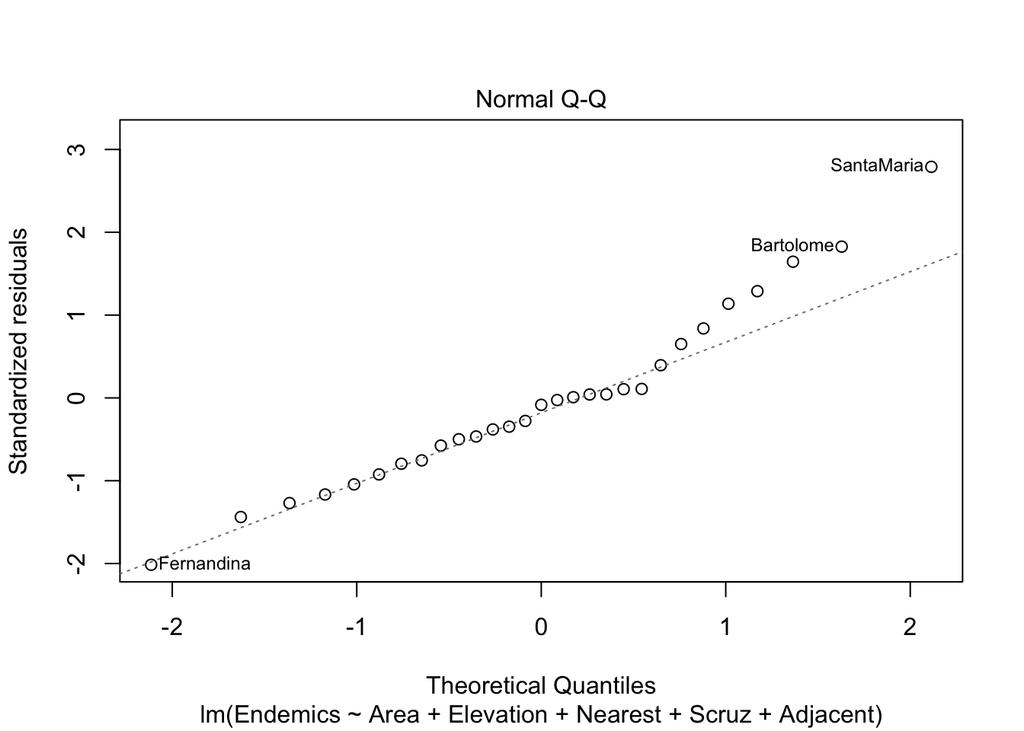

```r
plot(fitFull, which = 2)
```

Homogeneidad de varianzas usando plot

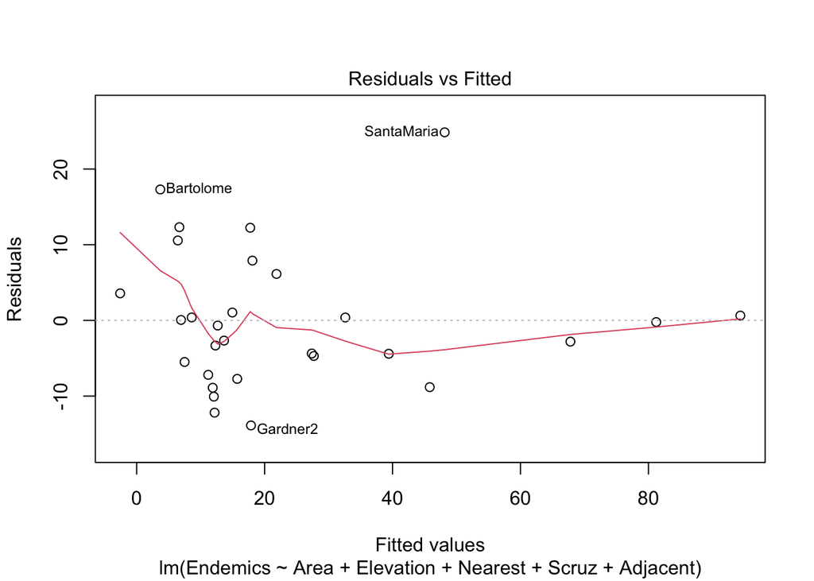

```r
plot(fitFull, which = 1)
```

### **Ejercicio 5.** Comparación modelo completo y modelo reducido

Proponga y elabore usted un modelo reducido para predecir el número de especies endémicas justificando su decisión. Compare su modelo reducido con el modelo completo usando los comandos **anova()** y **AIC()**. Responda:

¿Hay diferencias significativas entre ambos modelos?  
¿Cuál es el mejor modelo para predecir el número de especies endémicas según el criterio AIC?